# Diagonal integration — a complete walkthrough

**Diagonal integration** is the hard case: RNA and ATAC come from **different cells**, with no pairing and no shared cell ids. A method must align two populations using only shared feature space (e.g. gene-activity scores).

Everything below uses the same three calls, whatever the scenario:

```
mtb.scan(dataset)                    # what can I run?
res = mtb.run_all(dataset, category) # run it, with metrics
res.plot()                           # one figure
```

```python
import warnings; warnings.filterwarnings("ignore")
%matplotlib inline
from pathlib import Path
import pandas as pd
pd.set_option("display.max_colwidth", None)  # show `reason` in full - paths are long
import multibench as mtb

RESULTS = Path("results")          # stored results, so the comparisons reproduce
print("multibench", mtb.__version__)
```

```
multibench 0.1.0
```

```python
DATASET  = "D28"
CATEGORY = "diagonal"
FAST_METHOD = "online_iNMF"        # used for the quick live demos below
```

## 0. Which scenario is my data, and how do I lay it out?

Two calls answer what every new user hits first. `category` is a required argument everywhere, so start by seeing the legal values:

```python
mtb.list_categories()
```

```
{'vertical': 'Several modalities measured in the SAME cells (e.g. CITE-seq RNA+ADT, or 10x multiome RNA+ATAC). Cells are already matched.',
 'diagonal': 'Modalities measured in DIFFERENT cells, with no pairing (e.g. an RNA experiment and a separate ATAC experiment).',
 'mosaic': 'Several batches where only SOME share a modality; a paired batch bridges the others.',
 'cross': 'Several batches in which ALL modalities are present; the task is removing batch effects. (Spatial slice registration also lives here.)'}
```

And this prints exactly which filenames to use — including how **several batches** are named (numbered files in one flat directory):

```python
print(mtb.describe_layout(CATEGORY))
```

```
Put your files in  <data_path>/<DATASET_NAME>/ , e.g. ./data/MYDATA/
  (dataset = the folder NAME; data_path = the folder that CONTAINS it)

LAYOUT FOR DIAGONAL:
  rna.h5         <- the RNA cells
  atac.h5        <- the ATAC cells (gene activity); peak.h5 for peaks
  rna_cty.csv AND atac_cty.csv
                 <- ONE LABEL FILE PER MODALITY. The two cell sets are
                    disjoint, so they cannot share a single cty.csv.

  (numbered files live in the SAME flat dir; there is no batch column)

Modality roles and the filenames they resolve to:
    rna              rna.h5      - gene expression
    adt              adt.h5      - surface protein (CITE-seq antibody-derived tags)
    atac             atac.h5     - chromatin accessibility
    atac_gas         atac.h5     - ATAC as GENE-ACTIVITY scores  <-- note: plain atac.h5
    atac_peak        peak.h5     - ATAC as PEAKS                 <-- note: peak.h5, NOT atac.h5
    rna1/rna2/...    rna1.h5, rna2.h5, ... - one file per BATCH (mosaic/cross)
    adt1/adt2/...    adt1.h5, adt2.h5, ... - one file per BATCH (mosaic/cross)
    cty              cty.csv     - cell-type labels, ONE label set (vertical)
    rna_cty / atac_cty rna_cty.csv, atac_cty.csv - one label file PER MODALITY, used when RNA and ATAC come from different cells (diagonal)
    cty1/cty2/...    cty1.csv, cty2.csv, ... - one label file per BATCH (mosaic/cross)

!! Careful: the two ATAC representations do NOT map to the obvious names.
   gene-activity -> atac.h5   and   peaks -> peak.h5 .
   Putting a peak matrix in atac.h5 runs every method on the wrong
   representation without any error.

Modality files are HDF5 with the matrix under 'matrix/data'.
Use mtb.io.to_canonical(src, dst) to convert another layout.
Labels are CSV with one row per cell; the last column (or a column
named 'x') holds the cell type.

diagonal: Modalities measured in DIFFERENT cells, with no pairing (e.g. an RNA experiment and a separate ATAC experiment).


ENVIRONMENTS
  Every method runs in its OWN conda env (they need mutually
  incompatible framework versions). scan() marks a method NOT runnable
  if its env is missing, so a sweep never starts one that cannot finish.
      multibench env doctor          # what is needed / what is missing
      multibench env install --run   # build them all from lockfiles

Then:  mtb.scan('MYDATA')  ->  mtb.run_all('MYDATA', '<category>', out_dir=...)
```

## 1. What can I run on this data?

`scan` inspects the dataset and reports every method that can run — and, for the rest, exactly why not. Nothing is executed, so this is safe and instant.

```python
avail = mtb.scan(DATASET, category=CATEGORY)
avail[avail.runnable][["method", "modalities", "env", "output_kind",
                       "n_tunable", "runtime_tier", "observed_worst_sec"]]
```

|  | method | modalities | env | output_kind | n_tunable | runtime_tier | observed_worst_sec |
| --- | --- | --- | --- | --- | --- | --- | --- |
| 0 | Conos | rna+atac_gas | scmb_r | embedding | 0 | medium | 713 |
| 1 | GLUE | rna+atac_peak | glue | embedding | 0 | very_slow | 9031 |
| 2 | MultiMAP | rna+atac_peak+atac_gas | scmb_torch | embedding | 0 | slow | 2041 |
| 3 | Portal | rna+atac_gas | scmb_torch_v2 | embedding | 0 | medium | 401 |
| 4 | SCALEX | rna+atac_gas | scmb_torch | embedding | 0 | slow | 2233 |
| 5 | Seurat_v3 | rna+atac_peak+atac_gas | scmb_seurat4b | embedding | 0 | slow | 3365 |
| 6 | Seurat_v5 | rna+atac_peak | liger | embedding | 0 | very_slow | 15778 |
| 7 | VIPCCA | rna+atac_gas | scmb_vipcca27 | embedding | 0 | medium | 335 |
| 8 | iNMF | rna+atac_gas | scmb_r | embedding | 0 | fast | 121 |
| 9 | online_iNMF | rna+atac_gas | scmb_r | embedding | 0 | fast | 81 |
| 10 | scBridge | (data_dir) | scmb_torch | embedding | 13 | fast | 1 |
| 11 | scJoint | rna+atac_gas | scmb_scjoint | embedding | 21 | fast | 209 |
| 12 | sciCAN | rna+atac_gas | scmb_scican | embedding | 0 | very_slow | 15735 |
| 13 | uniPort | rna+atac_gas | scmb_torch | embedding | 1 | slow | 4133 |

Methods that are *not* runnable here come with a reason rather than a silent absence:

```python
not_ok = avail[~avail.runnable][["method", "modalities", "reason"]]
not_ok.head(5) if len(not_ok) else "(everything in this category runs on this dataset)"
```

```
'(everything in this category runs on this dataset)'
```

## 2. What can I tune?

`params_for` reports the parameters a method accepts. `defaults` are what the wrapper passes; `tunable` is what the **upstream script** exposes on its command line. An empty `tunable` means that method hardcodes its hyperparameters — it cannot be tuned without editing it, which this project never does.

```python
rows = []
for m in avail[avail.runnable]["method"]:
    p = mtb.params_for(m, CATEGORY, None if avail[avail.method==m].iloc[0]["modalities"]=="(data_dir)"
                       else avail[avail.method==m].iloc[0]["modalities"].split("+"))
    rows.append({"method": m, "n_tunable": len(p["tunable"]),
                 "defaults": p["defaults"],
                 "example": ", ".join(sorted(p["tunable"])[:4]) or "(hardcoded upstream)"})
pd.DataFrame(rows).sort_values("n_tunable", ascending=False).reset_index(drop=True)
```

|  | method | n_tunable | defaults | example |
| --- | --- | --- | --- | --- |
| 0 | scJoint | 21 | {} | atac_protein_paths, batch_size, center_weight, checkpoint |
| 1 | scBridge | 13 | {'umap_plot': True} | align_loss_epoch, batch_size, early_stop_acc, learning_rate |
| 2 | uniPort | 1 | {'seed': 1} | seed |
| 3 | Conos | 0 | {} | (hardcoded upstream) |
| 4 | GLUE | 0 | {} | (hardcoded upstream) |
| 5 | MultiMAP | 0 | {} | (hardcoded upstream) |
| 6 | Portal | 0 | {} | (hardcoded upstream) |
| 7 | SCALEX | 0 | {} | (hardcoded upstream) |
| 8 | Seurat_v3 | 0 | {} | (hardcoded upstream) |
| 9 | Seurat_v5 | 0 | {} | (hardcoded upstream) |
| 10 | VIPCCA | 0 | {} | (hardcoded upstream) |
| 11 | iNMF | 0 | {} | (hardcoded upstream) |
| 12 | online_iNMF | 0 | {} | (hardcoded upstream) |
| 13 | sciCAN | 0 | {} | (hardcoded upstream) |

## 3. Run one method

online_iNMF finishes in ~80 s. Tuning happens through `params=` — the same parameters `params_for` just listed.

```python
res = mtb.run_all(DATASET, CATEGORY,
                  methods=["online_iNMF"],
                  out_dir="/tmp/tutorial_diagonal")
res
```

```
[run_all] online_iNMF (diagonal/D28) ...
```

```
Cluster for cluster_0.2 with leiden
```

```
Cluster for cluster_0.4 with leiden
```

```
Cluster for cluster_0.6 with leiden
```

```
Cluster for cluster_0.8 with leiden
```

```
Cluster for cluster_1.0 with leiden
```

```
Cluster for cluster_1.2 with leiden
```

```
Cluster for cluster_1.4 with leiden
```

```
Cluster for cluster_1.6 with leiden
```

```
Cluster for cluster_1.8 with leiden
```

```
Cluster for cluster_2.0 with leiden
```

```
isolated labels: no more than 1 batches per label
isolated labels: ['CD4 TEM', 'CD8 TCM', 'Plasmablast', 'pDC']
```

[output not shown]

```
resolution: 0.2, max_f1: 0.017005196032120924
```

```
Cluster for iso_label_0.4 with leiden
```

```
resolution: 0.4, max_f1: 0.017142857142857144
```

```
Cluster for iso_label_0.6 with leiden
```

```
resolution: 0.6, max_f1: 0.0219435736677116
```

```
Cluster for iso_label_0.8 with leiden
```

```
resolution: 0.8, max_f1: 0.023591087811271297
```

```
Cluster for iso_label_1.0 with leiden
```

```
resolution: 1.0, max_f1: 0.023936170212765957
```

```
Cluster for iso_label_1.2 with leiden
```

```
resolution: 1.2, max_f1: 0.0297029702970297
```

```
Cluster for iso_label_1.4 with leiden
```

```
resolution: 1.4, max_f1: 0.04113110539845758
```

```
Cluster for iso_label_1.6 with leiden
```

```
resolution: 1.6, max_f1: 0.03508771929824561
```

```
Cluster for iso_label_1.8 with leiden
```

```
resolution: 1.8, max_f1: 0.033962264150943396
```

```
Cluster for iso_label_2.0 with leiden
```

```
resolution: 2.0, max_f1: 0.041379310344827586
```

```
optimised clustering against celltype
optimal cluster resolution: 2.0
optimal score: 0.041379310344827586
CD4 TEM: 0.041379310344827586
Cluster for iso_label_0.2 with leiden
```

```
resolution: 0.2, max_f1: 0.04283054003724395
```

```
Cluster for iso_label_0.4 with leiden
```

```
resolution: 0.4, max_f1: 0.04223369310183012
```

```
Cluster for iso_label_0.6 with leiden
```

```
resolution: 0.6, max_f1: 0.11659192825112108
```

```
Cluster for iso_label_0.8 with leiden
```

```
resolution: 0.8, max_f1: 0.10579345088161209
```

```
Cluster for iso_label_1.0 with leiden
```

```
resolution: 1.0, max_f1: 0.10983397190293742
```

```
Cluster for iso_label_1.2 with leiden
```

```
resolution: 1.2, max_f1: 0.10771113831089352
```

```
Cluster for iso_label_1.4 with leiden
```

```
resolution: 1.4, max_f1: 0.10357583230579531
```

```
Cluster for iso_label_1.6 with leiden
```

```
resolution: 1.6, max_f1: 0.08557457212713937
```

```
Cluster for iso_label_1.8 with leiden
```

```
resolution: 1.8, max_f1: 0.09976798143851508
```

```
Cluster for iso_label_2.0 with leiden
```

```
resolution: 2.0, max_f1: 0.0971563981042654
```

```
optimised clustering against celltype
optimal cluster resolution: 0.6
optimal score: 0.11659192825112108
CD8 TCM: 0.11659192825112108
Cluster for iso_label_0.2 with leiden
```

```
resolution: 0.2, max_f1: 0.011278195488721804
```

```
Cluster for iso_label_0.4 with leiden
```

```
resolution: 0.4, max_f1: 0.011278195488721804
```

```
Cluster for iso_label_0.6 with leiden
```

```
resolution: 0.6, max_f1: 0.011278195488721804
```

```
Cluster for iso_label_0.8 with leiden
```

```
resolution: 0.8, max_f1: 0.013333333333333334
```

```
Cluster for iso_label_1.0 with leiden
```

```
resolution: 1.0, max_f1: 0.01233616037008481
```

```
Cluster for iso_label_1.2 with leiden
```

```
resolution: 1.2, max_f1: 0.03333333333333333
```

```
Cluster for iso_label_1.4 with leiden
```

```
resolution: 1.4, max_f1: 0.0335195530726257
```

```
Cluster for iso_label_1.6 with leiden
```

```
resolution: 1.6, max_f1: 0.0335195530726257
```

```
Cluster for iso_label_1.8 with leiden
```

```
resolution: 1.8, max_f1: 0.02926829268292683
```

```
Cluster for iso_label_2.0 with leiden
```

```
resolution: 2.0, max_f1: 0.030303030303030304
```

```
optimised clustering against celltype
optimal cluster resolution: 1.4
optimal score: 0.0335195530726257
Plasmablast: 0.0335195530726257
Cluster for iso_label_0.2 with leiden
```

```
resolution: 0.2, max_f1: 0.08888888888888889
```

```
Cluster for iso_label_0.4 with leiden
```

```
resolution: 0.4, max_f1: 0.08333333333333333
```

```
Cluster for iso_label_0.6 with leiden
```

```
resolution: 0.6, max_f1: 0.0830188679245283
```

```
Cluster for iso_label_0.8 with leiden
```

```
resolution: 0.8, max_f1: 0.20754716981132076
```

```
Cluster for iso_label_1.0 with leiden
```

```
resolution: 1.0, max_f1: 0.20754716981132076
```

```
Cluster for iso_label_1.2 with leiden
```

```
resolution: 1.2, max_f1: 0.11956521739130435
```

```
Cluster for iso_label_1.4 with leiden
```

```
resolution: 1.4, max_f1: 0.18803418803418803
```

```
Cluster for iso_label_1.6 with leiden
```

```
resolution: 1.6, max_f1: 0.205607476635514
```

```
Cluster for iso_label_1.8 with leiden
```

```
resolution: 1.8, max_f1: 0.20754716981132076
```

```
Cluster for iso_label_2.0 with leiden
```

```
resolution: 2.0, max_f1: 0.20952380952380953
```

```
optimised clustering against celltype
optimal cluster resolution: 2.0
optimal score: 0.20952380952380953
pDC: 0.20952380952380953
```

[output not shown]

[output not shown]

[output not shown]

[output not shown]

```
Cluster for cluster_0.2 with leiden
```

```
Cluster for cluster_0.4 with leiden
```

```
Cluster for cluster_0.6 with leiden
```

```
Cluster for cluster_0.8 with leiden
```

```
Cluster for cluster_1.0 with leiden
```

```
Cluster for cluster_1.2 with leiden
```

```
Cluster for cluster_1.4 with leiden
```

```
Cluster for cluster_1.6 with leiden
```

```
Cluster for cluster_1.8 with leiden
```

```
Cluster for cluster_2.0 with leiden
```

```
isolated labels: no more than 1 batches per label
isolated labels: ['CD4 TEM', 'CD8 TCM', 'Plasmablast', 'pDC']
```

[output not shown]

```
resolution: 0.2, max_f1: 0.01646090534979424
```

```
Cluster for iso_label_0.4 with leiden
```

```
resolution: 0.4, max_f1: 0.02127659574468085
```

```
Cluster for iso_label_0.6 with leiden
```

```
resolution: 0.6, max_f1: 0.02120141342756184
```

```
Cluster for iso_label_0.8 with leiden
```

```
resolution: 0.8, max_f1: 0.02127659574468085
```

```
Cluster for iso_label_1.0 with leiden
```

```
resolution: 1.0, max_f1: 0.02127659574468085
```

```
Cluster for iso_label_1.2 with leiden
```

```
resolution: 1.2, max_f1: 0.0297029702970297
```

```
Cluster for iso_label_1.4 with leiden
```

```
resolution: 1.4, max_f1: 0.02962962962962963
```

```
Cluster for iso_label_1.6 with leiden
```

```
resolution: 1.6, max_f1: 0.02127659574468085
```

```
Cluster for iso_label_1.8 with leiden
```

```
resolution: 1.8, max_f1: 0.02127659574468085
```

```
Cluster for iso_label_2.0 with leiden
```

```
resolution: 2.0, max_f1: 0.021052631578947368
```

```
optimised clustering against celltype
optimal cluster resolution: 1.2
optimal score: 0.0297029702970297
CD4 TEM: 0.0297029702970297
Cluster for iso_label_0.2 with leiden
```

```
resolution: 0.2, max_f1: 0.020484171322160148
```

```
Cluster for iso_label_0.4 with leiden
```

```
resolution: 0.4, max_f1: 0.019709056780854058
```

```
Cluster for iso_label_0.6 with leiden
```

```
resolution: 0.6, max_f1: 0.02092675635276532
```

```
Cluster for iso_label_0.8 with leiden
```

```
resolution: 0.8, max_f1: 0.020151133501259445
```

```
Cluster for iso_label_1.0 with leiden
```

```
resolution: 1.0, max_f1: 0.028985507246376812
```

```
Cluster for iso_label_1.2 with leiden
```

```
resolution: 1.2, max_f1: 0.02631578947368421
```

```
Cluster for iso_label_1.4 with leiden
```

```
resolution: 1.4, max_f1: 0.023980815347721823
```

```
Cluster for iso_label_1.6 with leiden
```

```
resolution: 1.6, max_f1: 0.025
```

```
Cluster for iso_label_1.8 with leiden
```

```
resolution: 1.8, max_f1: 0.0273972602739726
```

```
Cluster for iso_label_2.0 with leiden
```

```
resolution: 2.0, max_f1: 0.024213075060532687
```

```
optimised clustering against celltype
optimal cluster resolution: 1.0
optimal score: 0.028985507246376812
CD8 TCM: 0.028985507246376812
Cluster for iso_label_0.2 with leiden
```

```
resolution: 0.2, max_f1: 0.008368200836820083
```

```
Cluster for iso_label_0.4 with leiden
```

```
resolution: 0.4, max_f1: 0.007194244604316547
```

```
Cluster for iso_label_0.6 with leiden
```

```
resolution: 0.6, max_f1: 0.008413001912045888
```

```
Cluster for iso_label_0.8 with leiden
```

```
resolution: 0.8, max_f1: 0.016666666666666666
```

```
Cluster for iso_label_1.0 with leiden
```

```
resolution: 1.0, max_f1: 0.016666666666666666
```

```
Cluster for iso_label_1.2 with leiden
```

```
resolution: 1.2, max_f1: 0.013605442176870748
```

```
Cluster for iso_label_1.4 with leiden
```

```
resolution: 1.4, max_f1: 0.015267175572519083
```

```
Cluster for iso_label_1.6 with leiden
```

```
resolution: 1.6, max_f1: 0.01652892561983471
```

```
Cluster for iso_label_1.8 with leiden
```

```
resolution: 1.8, max_f1: 0.03669724770642202
```

```
Cluster for iso_label_2.0 with leiden
```

```
resolution: 2.0, max_f1: 0.01968503937007874
```

```
optimised clustering against celltype
optimal cluster resolution: 1.8
optimal score: 0.03669724770642202
Plasmablast: 0.03669724770642202
Cluster for iso_label_0.2 with leiden
```

```
resolution: 0.2, max_f1: 0.008888888888888889
```

```
Cluster for iso_label_0.4 with leiden
```

```
resolution: 0.4, max_f1: 0.007575757575757576
```

```
Cluster for iso_label_0.6 with leiden
```

```
resolution: 0.6, max_f1: 0.007547169811320755
```

```
Cluster for iso_label_0.8 with leiden
```

```
resolution: 0.8, max_f1: 0.011764705882352941
```

```
Cluster for iso_label_1.0 with leiden
```

```
resolution: 1.0, max_f1: 0.011764705882352941
```

```
Cluster for iso_label_1.2 with leiden
```

```
resolution: 1.2, max_f1: 0.011764705882352941
```

```
Cluster for iso_label_1.4 with leiden
```

```
resolution: 1.4, max_f1: 0.011627906976744186
```

```
Cluster for iso_label_1.6 with leiden
```

```
resolution: 1.6, max_f1: 0.011764705882352941
```

```
Cluster for iso_label_1.8 with leiden
```

```
resolution: 1.8, max_f1: 0.011764705882352941
```

```
Cluster for iso_label_2.0 with leiden
```

```
resolution: 2.0, max_f1: 0.011627906976744186
```

```
optimised clustering against celltype
optimal cluster resolution: 0.8
optimal score: 0.011764705882352941
pDC: 0.011764705882352941
```

[output not shown]

[output not shown]

[output not shown]

```
[run_all]   -> CHAIN_OK (17.8s) 0.3749
```

[output not shown]

```
<BatchResult diagonal/D28: 1/1 with metrics, 0 failed>
```

```python
res.summary
```

|  | method | status | run_sec | output_kind | emb_shape | n_tunable | label_order | label_order_confidence | ARI | NMI | ASW | iASW | iF1 | cLISI | ASW_batch | GC | iLISI | kBET |
| --- | --- | --- | --- | --- | --- | --- | --- | --- | --- | --- | --- | --- | --- | --- | --- | --- | --- | --- |
| 0 | online_iNMF | CHAIN_OK | 17.8 | embedding | [11014, 20] | 0 | rna_cty.csv+atac_cty.csv | 0.9976 | 0.3749 | 0.469 | 0.4666 | 0.5271 | 0.1003 | None | 0.7777 | 0.7578 | None | None |

The metrics are already computed — `run_all` runs the method, picks the correct label order, and evaluates in one step.

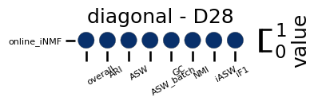

```python
res.plot()
```

## 4. Run everything

One call runs every applicable method and evaluates each:

```
res = mtb.run_all(DATASET, CATEGORY, out_dir="/tmp/diagonal_all",
                  timeout=4*3600,        # a hung method is recorded, not fatal
                  skip_existing=True)    # resume instead of repeating hours
print(res.failures)                      # ALWAYS check: failures are recorded, not raised
res.plot()
```

Next morning, re-plot **without re-running anything** (`run_all` saved it for you):

```
res = mtb.load_batch("/tmp/diagonal_all")
res.plot().savefig("compare.png")
```

> WARNING `skip_existing` reuses a method's existing output FILE. Do not combine it with a changed `params=` (you would silently get the old result, so `run_all` refuses it), and after a hard kill delete that method's directory, since a half-written file would be reused as if it had succeeded.

That takes from minutes to hours depending on the scenario, so here we load the stored results of exactly that sweep.

```python
summary = pd.read_csv(RESULTS / "summary_D28.csv")
# clustering metrics, then batch-correction metrics where the design has batches
cols = [c for c in ["method","status","run_sec","ARI","NMI","ASW",
                    "iASW","iF1","ASW_batch","GC"] if c in summary.columns]
summary[cols]
```

|  | method | status | run_sec | ARI | NMI | ASW | iASW | iF1 | ASW_batch | GC |
| --- | --- | --- | --- | --- | --- | --- | --- | --- | --- | --- |
| 0 | Conos | CHAIN_OK | 712.5 | 0.0004 | 0.0226 | 0.4301 | 0.3972 | 0.0335 | 0.8480 | 0.0738 |
| 1 | MultiMAP | CHAIN_OK | 2040.2 | 0.2368 | 0.4966 | 0.5529 | 0.4967 | 0.1462 | 0.6176 | 0.6701 |
| 2 | Portal | CHAIN_OK | 400.4 | 0.4798 | 0.6144 | 0.5186 | 0.5390 | 0.0839 | 0.8319 | 0.8602 |
| 3 | SCALEX | CHAIN_OK | 2232.3 | 0.5744 | 0.5859 | 0.5320 | 0.5436 | 0.1398 | 0.7994 | 0.8656 |
| 4 | Seurat_v3 | CHAIN_OK | 3364.6 | 0.6055 | 0.6339 | 0.4724 | 0.5333 | 0.1571 | 0.7800 | 0.8142 |
| 5 | VIPCCA | CHAIN_OK | 334.8 | 0.1518 | 0.3756 | 0.4785 | 0.4960 | 0.0842 | 0.6724 | 0.6202 |
| 6 | iNMF | CHAIN_OK | 120.2 | 0.4721 | 0.5136 | 0.4946 | 0.5363 | 0.0906 | 0.7940 | 0.7757 |
| 7 | online_iNMF | CHAIN_OK | 80.7 | 0.3749 | 0.4690 | 0.4666 | 0.5271 | 0.1003 | 0.7777 | 0.7578 |
| 8 | scJoint | CHAIN_OK | 208.9 | 0.6178 | 0.6377 | 0.5349 | 0.5675 | 0.3753 | 0.7571 | 0.8701 |
| 9 | sciCAN | CHAIN_OK | 15735.0 | 0.1877 | 0.3688 | 0.5133 | 0.4976 | 0.0900 | 0.7575 | 0.6270 |
| 10 | uniPort | CHAIN_OK | 4133.0 | 0.5994 | 0.6198 | 0.5320 | 0.5364 | 0.1505 | 0.8346 | 0.8678 |

### What a failure looks like

`.failures` is the table to check after every sweep, because a method that dies is **recorded, not raised** — the sweep keeps going. Here is a genuine failure: a method given an impossible hyperparameter. Note the sweep still returns normally and the error is in the table.

```python
broken = mtb.run_all(DATASET, CATEGORY, methods=[FAST_METHOD],
                     params={FAST_METHOD: {"epochs": -5}},   # nonsense on purpose
                     out_dir="/tmp/tut_fail", verbose=False)
print("failures:", len(broken.failures))
broken.failures
```

```
failures: 1
```

|  | method | status | error |
| --- | --- | --- | --- |
| 0 | online_iNMF | FAIL | KeyError: "online_iNMF does not accept ['epochs']; it accepts []. An empty set means it hardcodes its hyperparameters upstream." |

By contrast, if **nothing at all** can run — a mistyped dataset name, say — that is not a per-method failure, it means the request itself was wrong, so `run_all` raises instead of handing back an empty result that reads as success:

```python
try:
    mtb.run_all("NO_SUCH_DATASET", CATEGORY, out_dir="/tmp/tut_none")
except ValueError as e:
    print("ValueError:", str(e)[:160])
```

```
ValueError: nothing is runnable for dataset='NO_SUCH_DATASET' category='diagonal'. Inspect mtb.scan('NO_SUCH_DATASET', 'diagonal') for the full table. First reasons: ["File
```

### Reloading a finished sweep

`run_all` saves itself, so the morning after an overnight run you can reopen the results and re-plot **without recomputing anything**:

```python
reloaded = mtb.load_batch("/tmp/tut_fail")      # the sweep we just ran
print(type(reloaded).__name__, "|", len(reloaded), "method(s)")
reloaded.summary[["method", "status"]]
```

```
BatchResult | 1 method(s)
```

|  | method | status |
| --- | --- | --- |
| 0 | online_iNMF | FAIL |

> **Reading the metric columns.** This benchmark reports two families:
> - **Clustering / dimension reduction** — `ARI`, `NMI`, `ASW`. Always computed.
> - **Batch correction** — `iASW`, `iF1`, `ASW_batch`, `GC`. Computed automatically whenever the dataset has more than one batch; `run_all` derives the batch from which label file each cell came from.

> A blank cell has a specific meaning, and it is worth knowing which:
> - On a **single-batch** dataset (one `cty.csv`, i.e. vertical integration) the batch family does not exist at all — there is nothing to correct.
> - `iASW` / `iF1` measure **isolated labels** — cell types confined to a subset of batches. If every cell type appears in every batch there are none, so both are blank even though the dataset is multi-batch. That is the case on D45.
> - `cLISI` / `iLISI` need a compiled scIB extension that will not load against this machine's GLIBC, and `kBET` needs `rpy2`, which is not installed in the evaluation environment. Those three are environmental, not properties of your data.

## 5. The figure

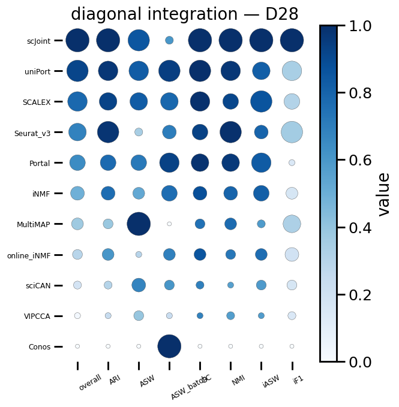

```python
long = pd.read_csv(RESULTS / "long_all_D28.csv")
fig = mtb.plot.bubble(long, title="diagonal integration — D28")
fig.set_dpi(110)
display(fig)
```

### Summarising across datasets

The bubble chart above compares methods **on this dataset**. To compare them **across** datasets, concatenate the tidy frames and use `plot.bar`, which is the summary the benchmark reports:

```
allf = pd.concat([pd.read_csv(p) for p in RESULTS.glob("long_all_*.csv")])
mtb.plot.bar(allf, title="overall across scenarios")        # every metric
mtb.plot.bar(allf, group="clustering")                      # one family
mtb.plot.bar(allf, group="batch")                           # the other
```

Each bar is a method's mean score over datasets; the dots behind it are its per-dataset scores, so a method that is uniformly good is distinguishable from one that averages well by winning a single dataset.

> The bubble chart encodes **radius = rank** — **rank 1 is the LARGEST bubble** — and **fill = value normalised within the plotted set**, darker being higher. Both are relative to what you plotted. Read the table beside it; with few methods a tiny gap can look decisive.

## 6. Using your OWN dataset

`describe_layout` above already printed the exact filenames for this scenario — **use those, not the role names.** They are not always the same: the `atac_gas` role lives in `atac.h5`, and `atac_peak` lives in `peak.h5`.

```
print(mtb.describe_layout(CATEGORY))   # the authoritative filename list
```

Then the same three calls work unchanged:

```
mtb.scan("MYDATA", category="diagonal")                     # confirm it is picked up
res = mtb.run_all("MYDATA", "diagonal", out_dir="out/")     # run everything
res.plot()
```

If `scan` says a method is not runnable, the `reason` column names the missing file — fix that and re-scan. Modality files are HDF5 with the matrix under `matrix/data`; `mtb.io.to_canonical` converts other layouts.